| title: “HarvardX Data Science Capstone” |
| --- |
| author: “Jorge Castro Martínez” |
| date: “2024-10-07” |
| output: |
| html_document: |
| toc: yes |
| toc_depth: 2 |
| number_sections: yes |
| code_folding: show |
| highlight: tango |
| theme: united |
| pdf_document: |
| toc: yes |
| toc_depth: 2 |
| number_sections: yes |
| latex_engine: xelatex |
| highlight: tango |
| urlcolor: blue |

# Introduction

#Although life expectancy is understood as the number of years that a person would expect to live on average from the moment of birth, it is important to note that, throughout their life, the conditions of the environment and the interaction of people have a direct impact. some factors such as demographic structure, income composition, level of immunization, among other determinants in health, environment and others.

#For this, exploratory data analysis is developed, as the first encounter with the data, with the objective of detailing and delimiting what is behind the data, as well as exploitative visualization by identifying what type of variables are present, in addition to identifying the number of observations, their periodicity and distribution.Therefore,the first part constitutes the univariate and bivariate exploitative analysis to know the independent variables and apply learned codes for all countries.

##And finally in the second section, the application of machine learning is carried out, through different machine learning techniques such as the Principal Component Analysis,the multiple linear regression model and classification that allow applying different algorithms and predicting results for decision making based on data and with scientific processes.But in this second moment, I only apply it to the group of countries of interest, the OECD countries.

#It should be noted that this project is the final presentation for the edX course, “HarvardX PH125.9x Data Science: Capstone. Its analysis can identify strengths and the need for attention to increase the life expectancy of the population in different countries.

#The data set aims to answer the following key questions:

#Do the various initially chosen prediction factors really affect life expectancy? What are the predictive variables that really affect life expectancy? #Should a country with a lower life expectancy value (<50) increase its healthcare spending to improve its average life expectancy? #How do infant and adult mortality rates affect life expectancy? #Does life expectancy have a positive or negative correlation with eating habits, lifestyle, alcohol and different diseases, etc.? #Does life expectancy have a positive or negative relationship with alcohol consumption? #Do developed or developing countries tend to have lower life expectancy?

# Methodology

#Subsequently, the machine learning technique is applied, related to the analysis of principal components for OECD countries, with the idea of analyzing and understanding the data set and visualizing it in a better way, capturing the most important and representative information of the database of the data, by reducing its dimension and grouping into correlated variables.

#Additionally, multiple and logistic regression is carried out for the variables and countries evaluated, in order to determine which are the main determining factors for achieving life expectancy.

# First part: Exploratory data analysis -EDA

```r
#Loading packages
#install.packages("readxl")
#installed.packages("faraway")
#install.packages("corrr")
#install.packages("ggcorrplot")
#install.packages("FactoMineR")
#install.packages("factoextra")
#install.packages("faraway")
#install.packages("corrplot")
#install.packages("psych")
#install.packages("lmtest")

#Loading libraries
library(tidyverse)
library(ggplot2)
library(readxl)
library(haven)
library(faraway)
library(readr)
library(dplyr)
library(corrr)
library(ggcorrplot)
library("FactoMineR")
library("factoextra")
library(faraway)
library(corrplot)
library(psych)
library(janitor)
library(car)
library (lmtest)
library(tseries)

#Read the csv file
setwd("C:/Users/jorge.castro/Desktop/PROYECTOS/Life EXp")

datas <- read.table("Life Expectancy Data.csv", header= TRUE,sep="," )
```

## *Analysis of dataframe*

```r
str(datas)
```

```
## 'data.frame':    2914 obs. of  22 variables:
##  $ Country                        : chr  "Afghanistan" "Afghanistan" "Afghanistan" "Afghanistan" ...
##  $ Year                           : int  2015 2014 2013 2012 2011 2010 2009 2008 2007 2006 ...
##  $ Status                         : chr  "Developing" "Developing" "Developing" "Developing" ...
##  $ Life.expectancy                : num  65 59.9 59.9 59.5 59.2 58.8 58.6 58.1 57.5 57.3 ...
##  $ Adult.Mortality                : int  263 271 268 272 275 279 281 287 295 295 ...
##  $ infant.deaths                  : int  62 64 66 69 71 74 77 80 82 84 ...
##  $ Alcohol                        : num  0.01 0.01 0.01 0.01 0.01 0.01 0.01 0.03 0.02 0.03 ...
##  $ percentage.expenditure         : num  71.3 73.5 73.2 78.2 7.1 ...
##  $ Hepatitis.B                    : int  65 62 64 67 68 66 63 64 63 64 ...
##  $ Measles                        : int  1154 492 430 2787 3013 1989 2861 1599 1141 1990 ...
##  $ BMI                            : num  19.1 18.6 18.1 17.6 17.2 16.7 16.2 15.7 15.2 14.7 ...
##  $ under.five.deaths              : int  83 86 89 93 97 102 106 110 113 116 ...
##  $ Polio                          : int  6 58 62 67 68 66 63 64 63 58 ...
##  $ Total.expenditure              : num  8.16 8.18 8.13 8.52 7.87 9.2 9.42 8.33 6.73 7.43 ...
##  $ Diphtheria                     : int  65 62 64 67 68 66 63 64 63 58 ...
##  $ HIV.AIDS                       : num  0.1 0.1 0.1 0.1 0.1 0.1 0.1 0.1 0.1 0.1 ...
##  $ GDP                            : num  584.3 612.7 631.7 670 63.5 ...
##  $ Population                     : num  33736494 327582 31731688 3696958 2978599 ...
##  $ thinness..1.19.years           : num  17.2 17.5 17.7 17.9 18.2 18.4 18.6 18.8 19 19.2 ...
##  $ thinness.5.9.years             : num  17.3 17.5 17.7 18 18.2 18.4 18.7 18.9 19.1 19.3 ...
##  $ Income.composition.of.resources: num  0.479 0.476 0.47 0.463 0.454 0.448 0.434 0.433 0.415 0.405 ...
##  $ Schooling                      : num  10.1 10 9.9 9.8 9.5 9.2 8.9 8.7 8.4 8.1 ...
```

```r
head(datas,n=5)
```

```
##       Country Year     Status Life.expectancy Adult.Mortality infant.deaths
## 1 Afghanistan 2015 Developing            65.0             263            62
## 2 Afghanistan 2014 Developing            59.9             271            64
## 3 Afghanistan 2013 Developing            59.9             268            66
## 4 Afghanistan 2012 Developing            59.5             272            69
## 5 Afghanistan 2011 Developing            59.2             275            71
##   Alcohol percentage.expenditure Hepatitis.B Measles  BMI under.five.deaths
## 1    0.01              71.279624          65    1154 19.1                83
## 2    0.01              73.523582          62     492 18.6                86
## 3    0.01              73.219243          64     430 18.1                89
## 4    0.01              78.184215          67    2787 17.6                93
## 5    0.01               7.097109          68    3013 17.2                97
##   Polio Total.expenditure Diphtheria HIV.AIDS       GDP Population
## 1     6              8.16         65      0.1 584.25921   33736494
## 2    58              8.18         62      0.1 612.69651     327582
## 3    62              8.13         64      0.1 631.74498   31731688
## 4    67              8.52         67      0.1 669.95900    3696958
## 5    68              7.87         68      0.1  63.53723    2978599
##   thinness..1.19.years thinness.5.9.years Income.composition.of.resources
## 1                 17.2               17.3                           0.479
## 2                 17.5               17.5                           0.476
## 3                 17.7               17.7                           0.470
## 4                 17.9               18.0                           0.463
## 5                 18.2               18.2                           0.454
##   Schooling
## 1      10.1
## 2      10.0
## 3       9.9
## 4       9.8
## 5       9.5
```

```r
tail(datas,5)
```

```
##       Country Year     Status Life.expectancy Adult.Mortality infant.deaths
## 2910 Zimbabwe 2004 Developing            44.3             723            27
## 2911 Zimbabwe 2003 Developing            44.5             715            26
## 2912 Zimbabwe 2002 Developing            44.8              73            25
## 2913 Zimbabwe 2001 Developing            45.3             686            25
## 2914 Zimbabwe 2000 Developing            46.0             665            24
##      Alcohol percentage.expenditure Hepatitis.B Measles  BMI under.five.deaths
## 2910    4.36                      0          68      31 27.1                42
## 2911    4.06                      0           7     998 26.7                41
## 2912    4.43                      0          73     304 26.3                40
## 2913    1.72                      0          76     529 25.9                39
## 2914    1.68                      0          79    1483 25.5                39
##      Polio Total.expenditure Diphtheria HIV.AIDS       GDP Population
## 2910    67              7.13         65     33.6 454.36665   12777511
## 2911     7              6.52         68     36.7 453.35116   12633897
## 2912    73              6.53         71     39.8  57.34834     125525
## 2913    76              6.16         75     42.1 548.58731   12366165
## 2914    78              7.10         78     43.5 547.35888   12222251
##      thinness..1.19.years thinness.5.9.years Income.composition.of.resources
## 2910                  9.4                9.4                           0.407
## 2911                  9.8                9.9                           0.418
## 2912                  1.2                1.3                           0.427
## 2913                  1.6                1.7                           0.427
## 2914                 11.0               11.2                           0.434
##      Schooling
## 2910       9.2
## 2911       9.5
## 2912      10.0
## 2913       9.8
## 2914       9.8
```

```r
ncol(datas)
```

```
## [1] 22
```

```r
nrow(datas)
```

```
## [1] 2914
```

```r
names(datas)
```

```
##  [1] "Country"                         "Year"
##  [3] "Status"                          "Life.expectancy"
##  [5] "Adult.Mortality"                 "infant.deaths"
##  [7] "Alcohol"                         "percentage.expenditure"
##  [9] "Hepatitis.B"                     "Measles"
## [11] "BMI"                             "under.five.deaths"
## [13] "Polio"                           "Total.expenditure"
## [15] "Diphtheria"                      "HIV.AIDS"
## [17] "GDP"                             "Population"
## [19] "thinness..1.19.years"            "thinness.5.9.years"
## [21] "Income.composition.of.resources" "Schooling"
```

```r
#datas
```

## Variable transformation

```r
dato<-datas


#Categorical variables
datac <-dato %>% mutate(across(contains(c("Country","Status")),~as.factor(.x)))

#Numerics variables
datan <-dato %>% mutate(across(contains(c("Year","Life.expectancy","Adult.Mortality","infant.deaths","Alcohol","percentage.expenditure","Diphtheria","HIV.AIDS","Measles","GDP","Population","thinness..1.19.years","thinness.5.9.years","Income.composition.of.resources","Schooling","Total.expenditure","Polio","BMI","Hepatitis.B")),~as.numeric(.x)))

data <-mutate(datac,datan)
#data
```

## Data cleaning and transformation

```r
#It is placed as a comment so as not to extend the deployment too much of codes
#View(data)

anyNA(data)
```

```
## [1] TRUE
```

```r
sum(is.na(data))
```

```
## [1] 2468
```

```r
#Transform to numeric

Life.expectancy <-as.numeric(unlist(data[,-1]))
Adult.Mortality <-as.numeric(unlist(data[,-2]))
infant.deaths <-as.numeric(unlist(data[,-3]))
Alcohol <-as.numeric(unlist(data[,-4]))
percentage.expenditure <-as.numeric(unlist(data[,-5]))
Hepatitis.B <-as.numeric(unlist(data[,-6]))
Measles <-as.numeric(unlist(data[,-7]))
BMI <-as.numeric(unlist(data[,-8]))
under.five.deaths <-as.numeric(unlist(data[,-9]))
Polio <-as.numeric(unlist(data[,-10]))
Total.expenditure <-as.numeric(unlist(data[,-11]))
Diphtheria <-as.numeric(unlist(data[,-12]))
HIV.AIDS <-as.numeric(unlist(data[,-13]))
GDP <-as.numeric(unlist(data[,-14]))
Population <-as.numeric(unlist(data[,-15]))
thinness..1.19.years <-as.numeric(unlist(data[,-16]))
thinness.5.9.years <-as.numeric(unlist(data[,-17]))
Income.composition.of.resources <-as.numeric(unlist(data[,-18]))
Schooling <-as.numeric(unlist(data[,-19]))

# Class type identification
class(data$Life.expectancy)
```

```
## [1] "numeric"
```

```r
class(data$Hepatitis.B)
```

```
## [1] "numeric"
```

```r
#It is placed as a comment so as not to extend the deployment too much of codes
#View(data)
```

## Mean value imputation

```r
data$Life.expectancy[is.na(data$Life.expectancy)] <-mean(data$Life.expectancy, na.rm=T) ##cambiar por la media de expectactiva de vida
data$Adult.Mortality[is.na(data$Adult.Mortality)] <-mean(data$Adult.Mortality, na.rm=T) ##cambiar por la media de Adult.Mortality
data$infant.deaths[is.na(data$infant.deaths)] <-mean(data$infant.deaths, na.rm=T) ##cambiar por la media de infant.deaths
data$Alcohol[is.na(data$Alcohol)] <-mean(data$Alcohol, na.rm=T) ##cambiar por la media de Alcohol
data$percentage.expenditure[is.na(data$percentage.expenditure)] <-mean(data$percentage.expenditure, na.rm=T) ##cambiar por la media de percentage.expenditure
data$Hepatitis.B[is.na(data$Hepatitis.B)] <-mean(data$Hepatitis.B, na.rm=T) ##cambiar por la media de Hepatitis.B
data$Measles[is.na(data$Measles)] <-mean(data$Measles, na.rm=T) ##cambiar por la media de Measles
data$BMI[is.na(data$BMI)] <-mean(data$BMI , na.rm=T) ##cambiar por la media de BMI
data$under.five.deaths[is.na(data$under.five.deaths)] <-mean(data$under.five.deaths, na.rm=T) ##cambiar por la media de under.five.deaths
data$Polio[is.na(data$Polio)] <-mean(data$Polio, na.rm=T) ##cambiar por la media de Polio
data$Total.expenditure[is.na(data$Total.expenditure)] <-mean(data$Total.expenditure, na.rm=T) ##cambiar por la media de Total.expenditure
data$Diphtheria[is.na(data$Diphtheria)] <-mean(data$Diphtheria, na.rm=T) ##cambiar por la media de Diphtheria
data$HIV.AIDS[is.na(data$HIV.AIDS)] <-mean(data$HIV.AIDS, na.rm=T) ##cambiar por la media de HIV.AIDS
data$GDP[is.na(data$GDP)] <-mean(data$GDP, na.rm=T) ##cambiar por la media de GDP
data$Population[is.na(data$Population)] <-mean(data$Population, na.rm=T) ##cambiar por la media de Population
data$thinness..1.19.years[is.na(data$thinness..1.19.years)] <-mean(data$thinness..1.19.years, na.rm=T) ##cambiar por la media de thinness..1.19.years
data$thinness.5.9.years[is.na(data$thinness.5.9.years)] <-mean(data$thinness.5.9.years, na.rm=T) ##cambiar por thinness.5.9.years
data$Income.composition.of.resources[is.na(data$Income.composition.of.resources)] <-mean(data$Income.composition.of.resources, na.rm=T) ##cambiar por Income.composition.of.resources
data$Schooling[is.na(data$Schooling)] <-mean(data$Schooling, na.rm=T) ##cambiar por Schooling
```

## Review of null and na.

###Also, it is possible to obtain values missing with data <- na.omit(data) or drop_na()

```r
sum(is.na(data$Life.expectancy))
```

```
## [1] 0
```

```r
sum(is.null(data$Life.expectancy))#no hay
```

```
## [1] 0
```

```r
sum(is.na(data))
```

```
## [1] 0
```

# *DESCRIPTION OF VARIABLES*

##assessing the concentration of data, identifying anomalies, outliers, relationships and others ## Univariate analysis

```r
datas %>% glimpse
```

```
## Rows: 2,914
## Columns: 22
## $ Country                         <chr> "Afghanistan", "Afghanistan", "Afghani…
## $ Year                            <int> 2015, 2014, 2013, 2012, 2011, 2010, 20…
## $ Status                          <chr> "Developing", "Developing", "Developin…
## $ Life.expectancy                 <dbl> 65.0, 59.9, 59.9, 59.5, 59.2, 58.8, 58…
## $ Adult.Mortality                 <int> 263, 271, 268, 272, 275, 279, 281, 287…
## $ infant.deaths                   <int> 62, 64, 66, 69, 71, 74, 77, 80, 82, 84…
## $ Alcohol                         <dbl> 0.01, 0.01, 0.01, 0.01, 0.01, 0.01, 0.…
## $ percentage.expenditure          <dbl> 71.279624, 73.523582, 73.219243, 78.18…
## $ Hepatitis.B                     <int> 65, 62, 64, 67, 68, 66, 63, 64, 63, 64…
## $ Measles                         <int> 1154, 492, 430, 2787, 3013, 1989, 2861…
## $ BMI                             <dbl> 19.1, 18.6, 18.1, 17.6, 17.2, 16.7, 16…
## $ under.five.deaths               <int> 83, 86, 89, 93, 97, 102, 106, 110, 113…
## $ Polio                           <int> 6, 58, 62, 67, 68, 66, 63, 64, 63, 58,…
## $ Total.expenditure               <dbl> 8.16, 8.18, 8.13, 8.52, 7.87, 9.20, 9.…
## $ Diphtheria                      <int> 65, 62, 64, 67, 68, 66, 63, 64, 63, 58…
## $ HIV.AIDS                        <dbl> 0.1, 0.1, 0.1, 0.1, 0.1, 0.1, 0.1, 0.1…
## $ GDP                             <dbl> 584.25921, 612.69651, 631.74498, 669.9…
## $ Population                      <dbl> 33736494, 327582, 31731688, 3696958, 2…
## $ thinness..1.19.years            <dbl> 17.2, 17.5, 17.7, 17.9, 18.2, 18.4, 18…
## $ thinness.5.9.years              <dbl> 17.3, 17.5, 17.7, 18.0, 18.2, 18.4, 18…
## $ Income.composition.of.resources <dbl> 0.479, 0.476, 0.470, 0.463, 0.454, 0.4…
## $ Schooling                       <dbl> 10.1, 10.0, 9.9, 9.8, 9.5, 9.2, 8.9, 8…
```

```r
#Status-categorical variable

Stated <-unique(data$Country)
Stated
```

```
##   [1] "Afghanistan"
##   [2] "Albania"
##   [3] "Algeria"
##   [4] "Angola"
##   [5] "Antigua and Barbuda"
##   [6] "Argentina"
##   [7] "Armenia"
##   [8] "Australia"
##   [9] "Austria"
##  [10] "Azerbaijan"
##  [11] "Bahamas"
##  [12] "Bahrain"
##  [13] "Bangladesh"
##  [14] "Barbados"
##  [15] "Belarus"
```

[output cut: 199 more lines]

```r
#data$Status[unique(data$Country)]

Statuss <-factor(sample(c("Developed", "Developing"),
                        size=length(data$Status),replace = TRUE))
#It is placed as a comment so as not to extend the deployment too much of codes
#Statuss
Tipodepais<-data$Status
table(Tipodepais)
```

```
## Tipodepais
##  Developed Developing
##        512       2402
```

```r
sum(Tipodepais=="Developed")
```

```
## [1] 512
```

```r
Statust<-prop.table(table(Tipodepais))
Statust
```

```
## Tipodepais
##  Developed Developing
##  0.1757035  0.8242965
```

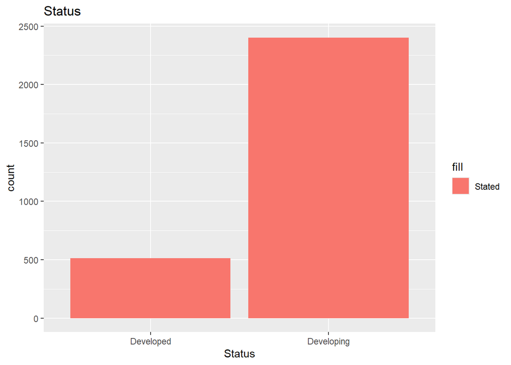

```r
ggplot(data)+
  aes(x=Status,fill="Stated")+
  geom_bar()+
  ggtitle("Status")
```

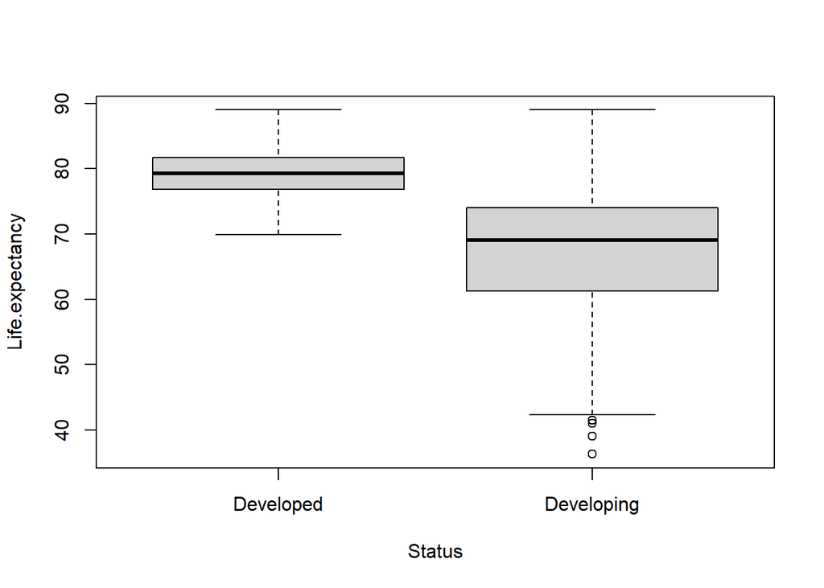

```r
boxplot(Life.expectancy ~ Status, data = data)
```

```r
#Country

length(data$Country[data$Country == "Costa Rica"])#number of times CR appears
```

```
## [1] 16
```

```r
CostaRicacountryy<-  data %>%
  filter(Country=="Costa Rica",
         Year==2014)#information about a specific variable
CostaRicacountryy
```

```
##      Country Year     Status Life.expectancy Adult.Mortality infant.deaths
## 1 Costa Rica 2014 Developing            79.5              96             1
##   Alcohol percentage.expenditure Hepatitis.B Measles  BMI under.five.deaths
## 1    3.45               384.5129          91       1 59.5                 1
##   Polio Total.expenditure Diphtheria HIV.AIDS      GDP Population
## 1    91              9.31         91      0.1 1647.442    4757575
##   thinness..1.19.years thinness.5.9.years Income.composition.of.resources
## 1                  1.7                1.7                           0.768
##   Schooling
## 1      13.9
```

```r
#View(CostaRicacountryy)
summary(CostaRicacountryy)
```

```
##    Country               Year         Status          Life.expectancy
##  Length:1           Min.   :2014   Length:1           Min.   :79.5
##  Class :character   1st Qu.:2014   Class :character   1st Qu.:79.5
##  Mode  :character   Median :2014   Mode  :character   Median :79.5
##                     Mean   :2014                      Mean   :79.5
##                     3rd Qu.:2014                      3rd Qu.:79.5
##                     Max.   :2014                      Max.   :79.5
##  Adult.Mortality infant.deaths    Alcohol     percentage.expenditure
##  Min.   :96      Min.   :1     Min.   :3.45   Min.   :384.5
##  1st Qu.:96      1st Qu.:1     1st Qu.:3.45   1st Qu.:384.5
##  Median :96      Median :1     Median :3.45   Median :384.5
##  Mean   :96      Mean   :1     Mean   :3.45   Mean   :384.5
##  3rd Qu.:96      3rd Qu.:1     3rd Qu.:3.45   3rd Qu.:384.5
##  Max.   :96      Max.   :1     Max.   :3.45   Max.   :384.5
##   Hepatitis.B    Measles       BMI       under.five.deaths     Polio
##  Min.   :91   Min.   :1   Min.   :59.5   Min.   :1         Min.   :91
##  1st Qu.:91   1st Qu.:1   1st Qu.:59.5   1st Qu.:1         1st Qu.:91
##  Median :91   Median :1   Median :59.5   Median :1         Median :91
##  Mean   :91   Mean   :1   Mean   :59.5   Mean   :1         Mean   :91
##  3rd Qu.:91   3rd Qu.:1   3rd Qu.:59.5   3rd Qu.:1         3rd Qu.:91
##  Max.   :91   Max.   :1   Max.   :59.5   Max.   :1         Max.   :91
##  Total.expenditure   Diphtheria    HIV.AIDS        GDP         Population
##  Min.   :9.31      Min.   :91   Min.   :0.1   Min.   :1647   Min.   :4757575
##  1st Qu.:9.31      1st Qu.:91   1st Qu.:0.1   1st Qu.:1647   1st Qu.:4757575
##  Median :9.31      Median :91   Median :0.1   Median :1647   Median :4757575
##  Mean   :9.31      Mean   :91   Mean   :0.1   Mean   :1647   Mean   :4757575
##  3rd Qu.:9.31      3rd Qu.:91   3rd Qu.:0.1   3rd Qu.:1647   3rd Qu.:4757575
##  Max.   :9.31      Max.   :91   Max.   :0.1   Max.   :1647   Max.   :4757575
##  thinness..1.19.years thinness.5.9.years Income.composition.of.resources
##  Min.   :1.7          Min.   :1.7        Min.   :0.768
##  1st Qu.:1.7          1st Qu.:1.7        1st Qu.:0.768
##  Median :1.7          Median :1.7        Median :0.768
##  Mean   :1.7          Mean   :1.7        Mean   :0.768
##  3rd Qu.:1.7          3rd Qu.:1.7        3rd Qu.:0.768
##  Max.   :1.7          Max.   :1.7        Max.   :0.768
##    Schooling
##  Min.   :13.9
##  1st Qu.:13.9
##  Median :13.9
##  Mean   :13.9
##  3rd Qu.:13.9
##  Max.   :13.9
```

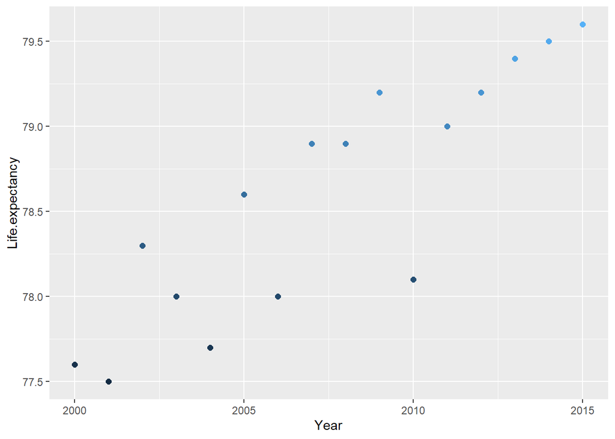

```r
data  %>%
  filter(Country == "Costa Rica") %>%
  ggplot(aes(Year, Life.expectancy,col = Life.expectancy)) +
  geom_point(size = 2)+
  theme(legend.position = "none")
```

```r
#Comparison CR vs 2 countries
data %>%
  filter(Year == 2014 & Country %in% c("Costa Rica", "Canada", "Chile")) %>%
  select(Life.expectancy, Country, Year)
```

```
##   Life.expectancy    Country Year
## 1            82.0     Canada 2014
## 2            83.0      Chile 2014
## 3            79.5 Costa Rica 2014
```

```r
#Life Expectancy

summary(data$Life.expectancy)
```

```
##    Min. 1st Qu.  Median    Mean 3rd Qu.    Max.
##   36.30   63.30   72.10   69.29   75.70   89.00
```

```r
#Life_Adult <-data %>% select(Adult.Mortality, Country) %>% filter(Year==2015 & Country=="Costa Rica")
#Life_Adult

#Life_Adult_world <-data %>% select(Adult.Mortality, Country) %>% filter(Year==2015)
#Life_Adult_world


data %>%
  group_by(data$Country) %>%
  summarize(min_size = min(Life.expectancy, na.rm = TRUE))
```

```
## # A tibble: 214 × 2
##    `data$Country`      min_size
##    <chr>                  <dbl>
##  1 Afghanistan             54.8
##  2 Albania                 72.6
##  3 Algeria                 71.3
##  4 Angola                  45.3
##  5 Antigua and Barbuda     73.6
##  6 Argentina               74
##  7 Armenia                 72
##  8 Australia               79.5
##  9 Austria                 78.1
## 10 Azerbaijan              66.6
## # ℹ 204 more rows
```

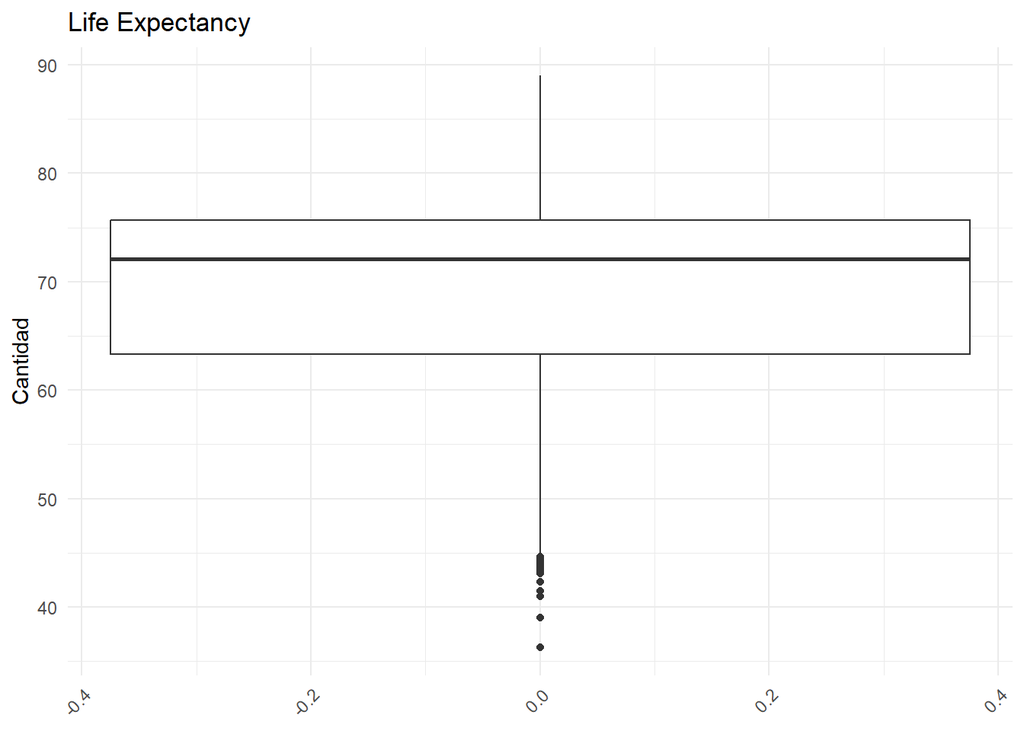

```r
#Life.expectancy

ggplot(data)+
  aes(x=, y=Life.expectancy)+
  geom_boxplot()+
  labs(title = "Life Expectancy", y = "Cantidad") +
  theme_minimal()+
  theme(axis.text.x = element_text(angle = 45, hjust = 1))
```

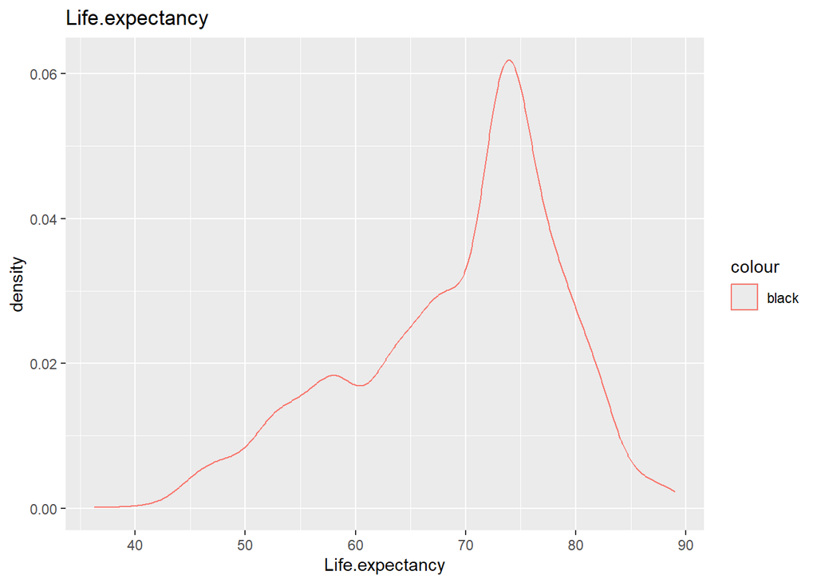

```r
#Distribution by age
data %>% ggplot((aes(x=Life.expectancy)))+
  geom_density(aes(x=Life.expectancy,binwidth = 1, color = "black"))+
  ggtitle("Life.expectancy")
```

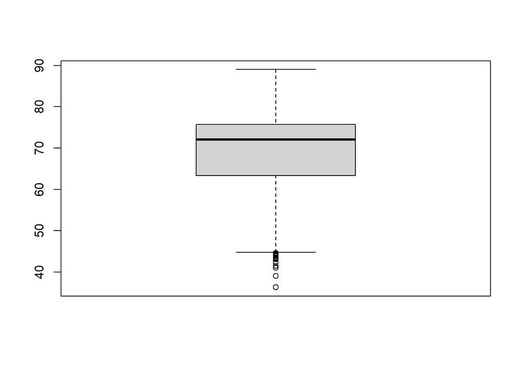

```r
boxplot(data$Life.expectancy)
```

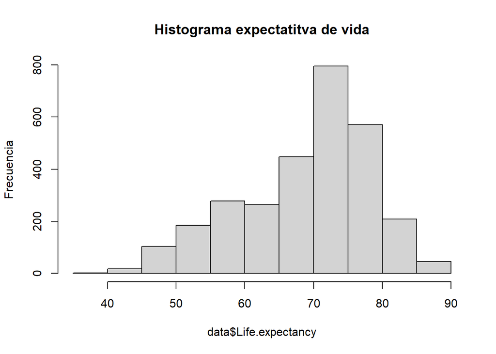

```r
hist(data$Life.expectancy, main="Histograma expectatitva de vida",ylab="Frecuencia")
```

```r
#Years of life expectancy

mean(data$Life.expectancy)
```

```
## [1] 69.2947
```

```r
min(data$Life.expectancy)
```

```
## [1] 36.3
```

```r
max(data$Life.expectancy)
```

```
## [1] 89
```

```r
#It is placed as a comment so as not to extend the deployment too much of codes

#data %>% select(Life.expectancy, Country) %>% filter(Life.expectancy <=50)
match(50,data$Life.expectancy)
```

```
## [1] 1479
```

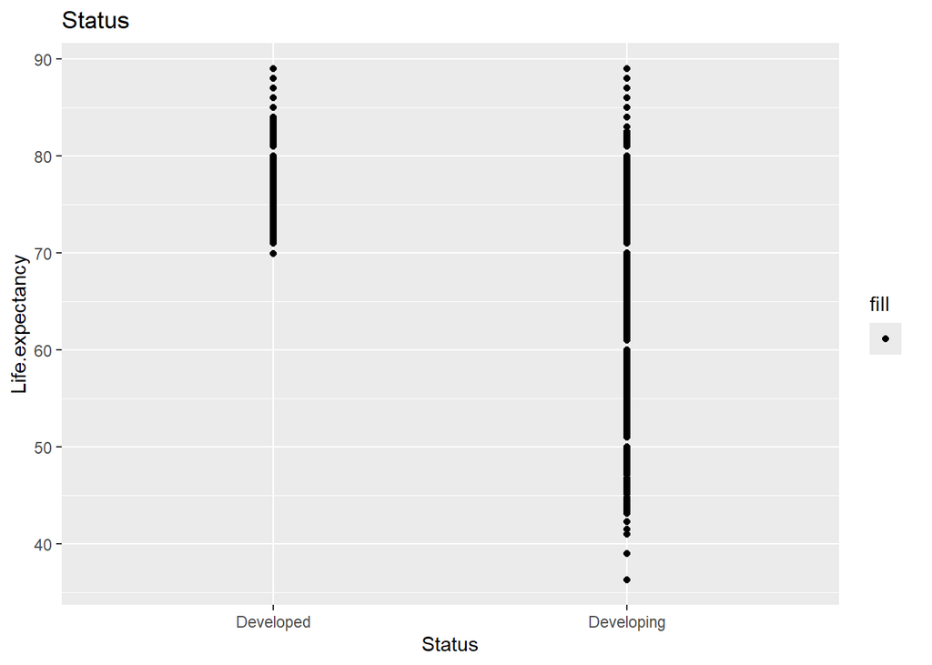

```r
#data %>% select(Life.expectancy, Country) %>% filter(Life.expectancy >=80)
#data %>% select(Life.expectancy, Country, Year) %>% filter(Country=="Costa Rica")

ggplot(data)+
  aes(x=Status,y=Life.expectancy,fill="") +
  geom_point()+
  ggtitle("Status")
```

```r
#GDP

summary(data$GDP)
```

```
##      Min.   1st Qu.    Median      Mean   3rd Qu.      Max.
##      1.68    572.94   2970.19   7483.16   7483.16 119172.74
```

```r
sd((data$GDP))
```

```
## [1] 13190.81
```

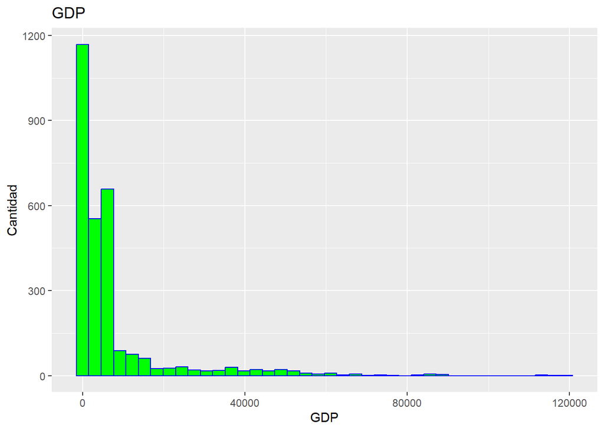

```r
data %>% ggplot((aes(x=GDP)))+
  geom_histogram(color="Blue",fill="green",bins=40)+
  labs(title = "GDP", y = "Cantidad")
```

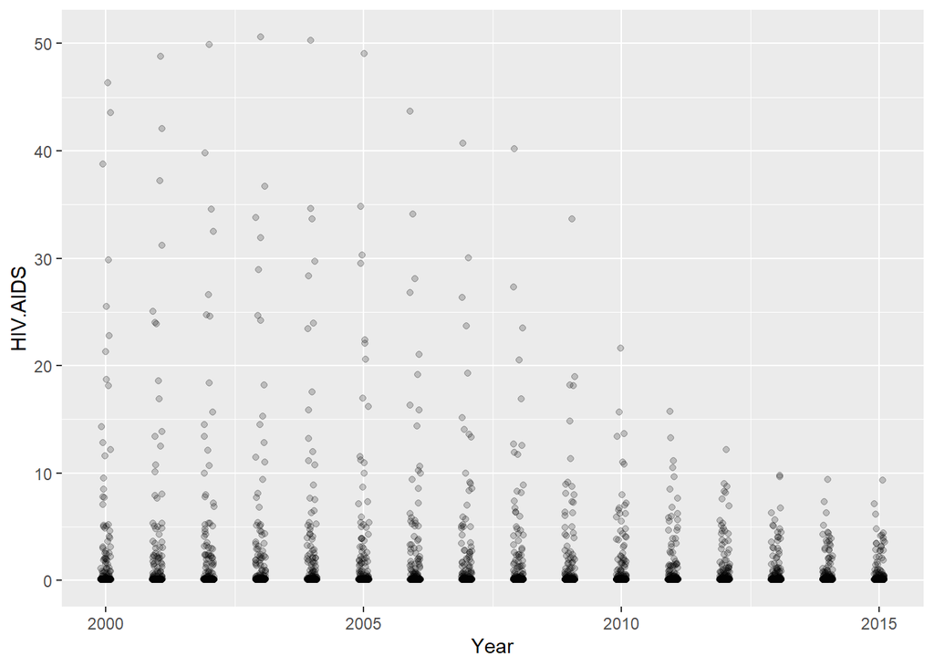

```r
#HIV.AIDS

data  %>% ggplot(aes(Year,HIV.AIDS)) + geom_jitter(width = 0.1, alpha = 0.2)
```

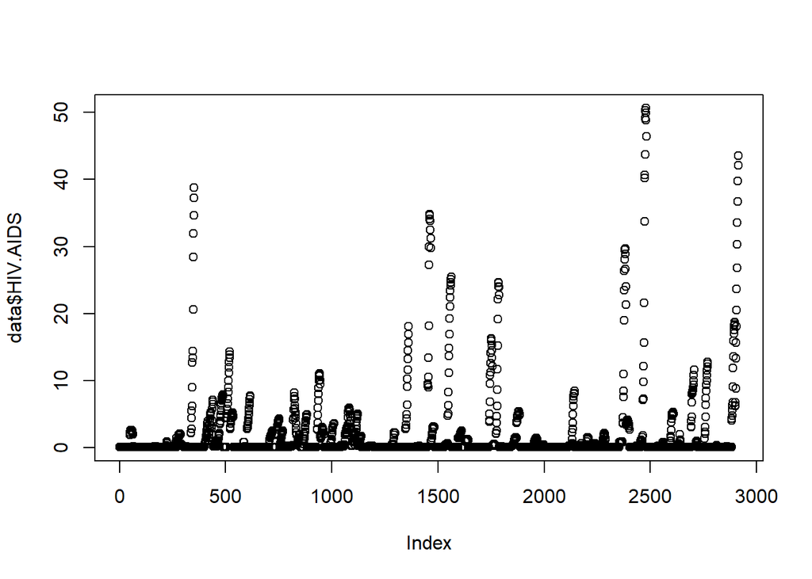

```r
plot(data$HIV.AIDS)
```

```r
summary(data$HIV.AIDS)
```

```
##    Min. 1st Qu.  Median    Mean 3rd Qu.    Max.
##   0.100   0.100   0.100   1.743   0.800  50.600
```

```r
sd((data$HIV.AIDS))
```

```
## [1] 5.09424
```

```r
data %>%
  group_by(data$Year) %>%
  summarize(max = max(HIV.AIDS, na.rm = TRUE))
```

```
## # A tibble: 16 × 2
##    `data$Year`   max
##          <dbl> <dbl>
##  1        2000  46.4
##  2        2001  48.8
##  3        2002  49.9
##  4        2003  50.6
##  5        2004  50.3
##  6        2005  49.1
##  7        2006  43.7
##  8        2007  40.7
##  9        2008  40.2
## 10        2009  33.7
## 11        2010  21.6
## 12        2011  15.7
## 13        2012  12.2
## 14        2013   9.8
## 15        2014   9.4
## 16        2015   9.3
```

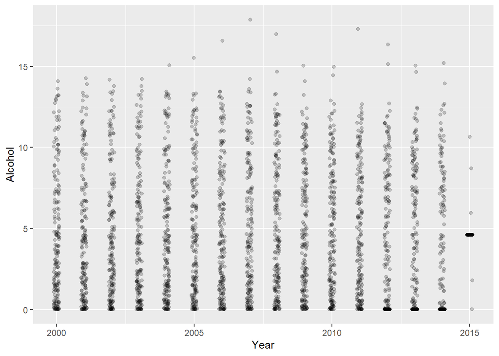

```r
#Alcohol
data  %>% ggplot(aes(Year,Alcohol)) + geom_jitter(width = 0.1, alpha = 0.2)
```

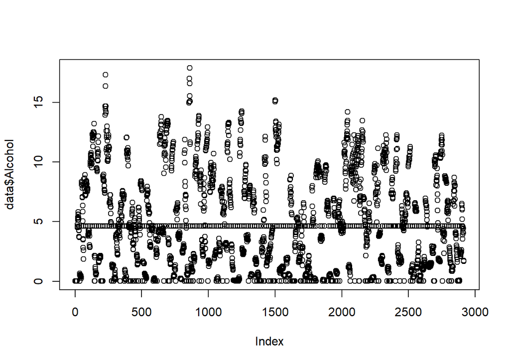

```r
plot(data$Alcohol)
```

```r
summary(data$Alcohol)
```

```
##    Min. 1st Qu.  Median    Mean 3rd Qu.    Max.
##   0.010   1.073   4.170   4.613   7.438  17.870
```

```r
sd((data$Alcohol))
```

```
## [1] 3.929774
```

# Bivariate analysis

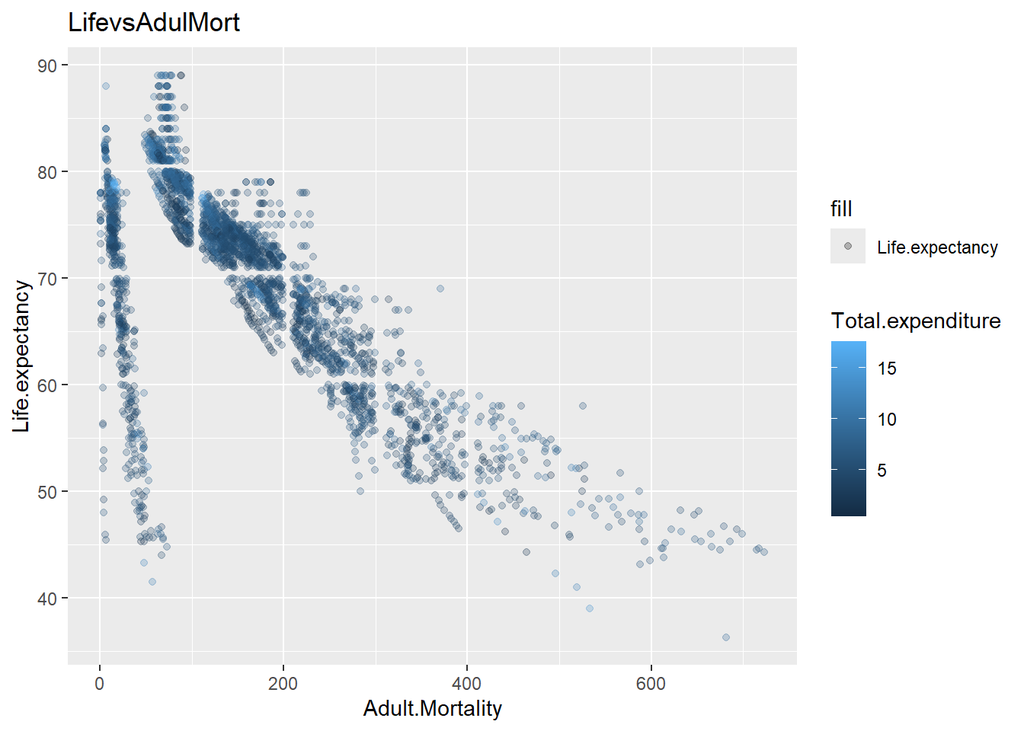

```r
#Life.expectancy vs Adult.Mortality

LifevsAdulMort<-ggplot(data)+aes(x=Adult.Mortality, y=Life.expectancy, color=Total.expenditure,fill="Life.expectancy")+
  geom_point(alpha=0.25)+
  ggtitle("LifevsAdulMort")
LifevsAdulMort
```

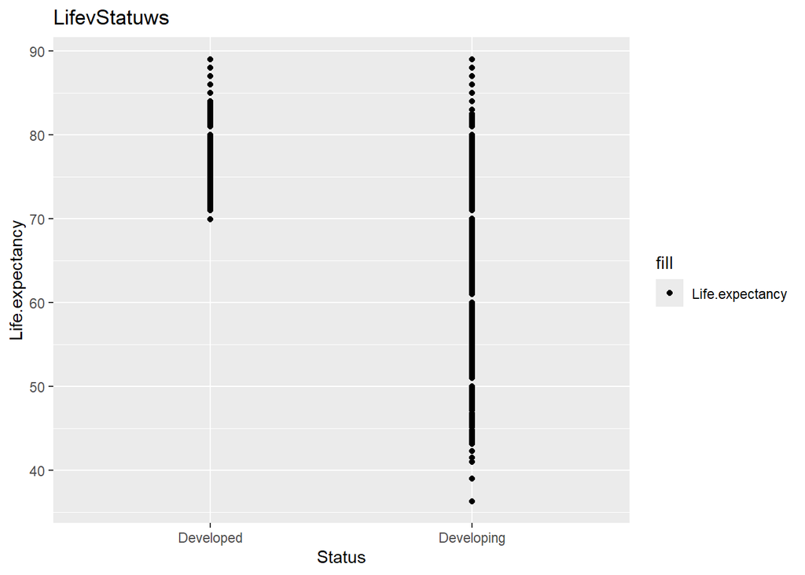

```r
#Life.expectancy vs Status

LifevStatuws<-ggplot(data)+ geom_point (aes(x=Status, y=Life.expectancy,fill="Life.expectancy")) +
  ggtitle("LifevStatuws")
LifevStatuws
```

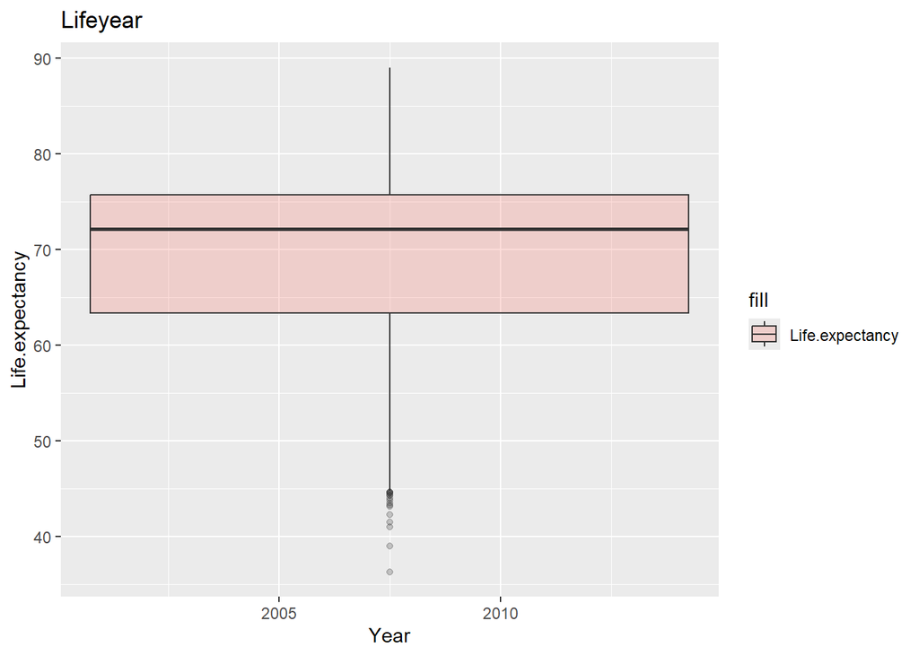

```r
#Life.expectancy vs Year

Lifeyear2<-ggplot(data)+aes(x=Year, y=Life.expectancy,fill="Life.expectancy")+
  geom_boxplot(alpha=0.25)+
  ggtitle("Lifeyear")
Lifeyear2
```

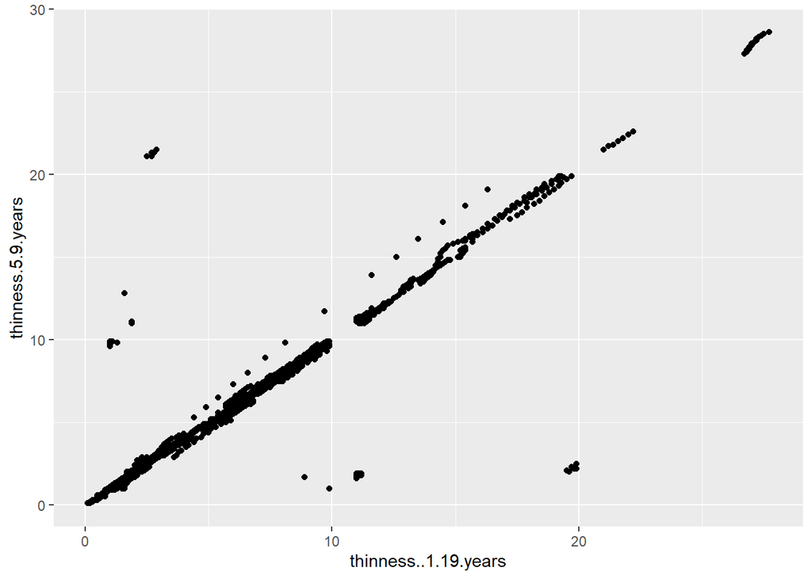

```r
#thinness..1.19.years vs thinness.5.9.years

thinness1.19vs..5..9<-ggplot(data,color="red",size="cty")+
  aes(x=thinness..1.19.years, thinness.5.9.years)+
  geom_point()

thinness1.19vs..5..9
```

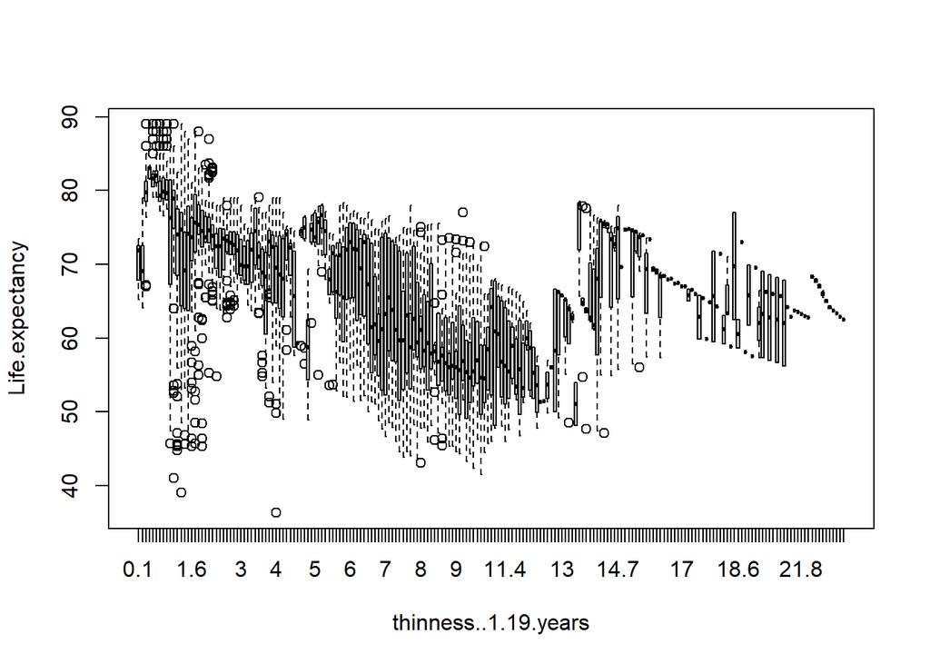

```r
boxplot(Life.expectancy~thinness..1.19.years, data = data)
```

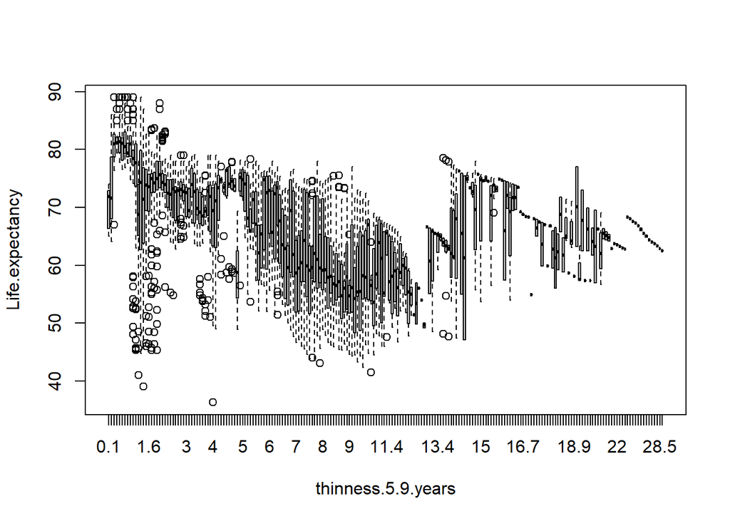

```r
boxplot(Life.expectancy~ thinness.5.9.years, data = data)
```

# Second part: Application of machine learning

## *Principal Components Analysis is applied as an unsupervised technique and multiple and logistic regression as a supervised analysis*.

## OECD countries are prioritized for carrying out this second part.

```r
## Create the List of OECD Member Countries

ocde_countries <- c("Australia", "Austria", "Belgium", "Canada", "Chile", "Colombia", "Czech Republic","Denmark", "Estonia", "Finland", "France", "Germany", "Greece", "Hungary",
                    "Iceland", "Ireland", "Israel", "Italy", "Japan", "Korea", "Latvia",
                    "Lithuania", "Luxembourg", "Mexico", "Netherlands", "New Zealand", "Norway",
                    "Poland", "Portugal", "Slovak Republic", "Slovenia", "Spain", "Sweden",
                    "Switzerland", "Turkey", "United Kingdom", "United States","Costa Rica")


length(ocde_countries)
```

```
## [1] 38
```

```r
#Use the list to filter the data before performing PCA
# Filter data to include only OECD countries

data_ocde <- data %>% filter(Country %in% ocde_countries)
length(data_ocde)
```

```
## [1] 22
```

```r
# Show the first rows of the filtered dataframe
head(data_ocde)
```

```
##     Country Year    Status Life.expectancy Adult.Mortality infant.deaths
## 1 Australia 2015 Developed            82.8              59             1
## 2 Australia 2014 Developed            82.7               6             1
## 3 Australia 2013 Developed            82.5              61             1
## 4 Australia 2012 Developed            82.3              61             1
## 5 Australia 2011 Developed            82.0              63             1
## 6 Australia 2010 Developed            81.9              64             1
##   Alcohol percentage.expenditure Hepatitis.B Measles  BMI under.five.deaths
## 1   4.613                  0.000          93      74 66.6                 1
## 2   9.710              10769.363          91     340 66.1                 1
## 3   9.870              11734.854          91     158 65.5                 1
## 4  10.030              11714.999          91     199 65.0                 1
## 5  10.300              10986.265          92     190 64.4                 1
## 6  10.520               8875.786          92      70 63.9                 1
##   Polio Total.expenditure Diphtheria HIV.AIDS      GDP Population
```

[output cut: 20 more lines]

```r
str(data_ocde)
```

```
## 'data.frame':    528 obs. of  22 variables:
##  $ Country                        : chr  "Australia" "Australia" "Australia" "Australia" ...
##  $ Year                           : num  2015 2014 2013 2012 2011 ...
##  $ Status                         : chr  "Developed" "Developed" "Developed" "Developed" ...
##  $ Life.expectancy                : num  82.8 82.7 82.5 82.3 82 81.9 81.7 81.3 81.3 81.2 ...
##  $ Adult.Mortality                : num  59 6 61 61 63 64 66 66 66 66 ...
##  $ infant.deaths                  : num  1 1 1 1 1 1 1 1 1 1 ...
##  $ Alcohol                        : num  4.61 9.71 9.87 10.03 10.3 ...
##  $ percentage.expenditure         : num  0 10769 11735 11715 10986 ...
##  $ Hepatitis.B                    : num  93 91 91 91 92 92 94 94 94 95 ...
##  $ Measles                        : num  74 340 158 199 190 70 104 65 11 0 ...
##  $ BMI                            : num  66.6 66.1 65.5 65 64.4 63.9 63.4 62.9 62.5 62 ...
##  $ under.five.deaths              : num  1 1 1 1 1 1 1 1 2 2 ...
##  $ Polio                          : num  93 92 91 92 92 92 92 92 92 92 ...
##  $ Total.expenditure              : num  5.94 9.42 9.36 9.36 9.2 ...
##  $ Diphtheria                     : num  93 92 91 92 92 92 92 92 92 92 ...
##  $ HIV.AIDS                       : num  0.1 0.1 0.1 0.1 0.1 0.1 0.1 0.1 0.1 0.1 ...
##  $ GDP                            : num  56554 62215 67792 67678 62245 ...
##  $ Population                     : num  23789338 2346694 23117353 22728254 223424 ...
##  $ thinness..1.19.years           : num  0.6 0.6 0.6 0.6 0.6 0.7 0.7 0.7 0.7 0.7 ...
##  $ thinness.5.9.years             : num  0.6 0.6 0.6 0.6 0.6 0.6 0.6 0.6 0.6 0.6 ...
##  $ Income.composition.of.resources: num  0.937 0.936 0.933 0.93 0.927 0.927 0.925 0.921 0.918 0.915 ...
##  $ Schooling                      : num  20.4 20.4 20.3 20.1 19.8 19.5 19.1 19.1 19 20.3 ...
```

```r
colSums(is.na(data_ocde))
```

```
##                         Country                            Year
##                               0                               0
##                          Status                 Life.expectancy
##                               0                               0
##                 Adult.Mortality                   infant.deaths
##                               0                               0
##                         Alcohol          percentage.expenditure
##                               0                               0
##                     Hepatitis.B                         Measles
##                               0                               0
##                             BMI               under.five.deaths
##                               0                               0
##                           Polio               Total.expenditure
##                               0                               0
##                      Diphtheria                        HIV.AIDS
##                               0                               0
##                             GDP                      Population
##                               0                               0
##            thinness..1.19.years              thinness.5.9.years
##                               0                               0
## Income.composition.of.resources                       Schooling
##                               0                               0
```

```r
#Add numerical variables by country (filtered)
# Average numerical variables by country for OECD countries

data_agg_ocde <- data_ocde %>%
  group_by(Country) %>%
  summarize(across(where(is.numeric), mean))
```

```r
## Delete the Year and HIV/AIDS column

data_agg_ocde2 <-data_agg_ocde[,-c(2,15)]
data_agg_ocde2
```

```
## # A tibble: 33 × 19
##    Country    Life.expectancy Adult.Mortality infant.deaths Alcohol
##    <chr>                <dbl>           <dbl>         <dbl>   <dbl>
##  1 Australia             81.8            63.2          1       9.81
##  2 Austria               81.5            65.8          0      11.8
##  3 Belgium               80.7            70.2          0.25   10.6
##  4 Canada                81.7            64.6          2       7.84
##  5 Chile                 79.4            63.6          2       6.83
##  6 Colombia              73.3           124.          13.9     4.43
##  7 Costa Rica            78.6            69.4          1       3.97
##  8 Denmark               79.3            66.1          0      10.3
##  9 Estonia               74.9           170.           0       8.74
## 10 Finland               80.7            68.9          0       9.24
## # ℹ 23 more rows
## # ℹ 14 more variables: percentage.expenditure <dbl>, Hepatitis.B <dbl>,
## #   Measles <dbl>, BMI <dbl>, under.five.deaths <dbl>, Polio <dbl>,
## #   Total.expenditure <dbl>, Diphtheria <dbl>, GDP <dbl>, Population <dbl>,
## #   thinness..1.19.years <dbl>, thinness.5.9.years <dbl>,
## #   Income.composition.of.resources <dbl>, Schooling <dbl>
```

```r
# Show the first rows of the added dataframe
data_agg_ocde
```

```
## # A tibble: 33 × 21
##    Country     Year Life.expectancy Adult.Mortality infant.deaths Alcohol
##    <chr>      <dbl>           <dbl>           <dbl>         <dbl>   <dbl>
##  1 Australia  2008.            81.8            63.2          1       9.81
##  2 Austria    2008.            81.5            65.8          0      11.8
##  3 Belgium    2008.            80.7            70.2          0.25   10.6
##  4 Canada     2008.            81.7            64.6          2       7.84
##  5 Chile      2008.            79.4            63.6          2       6.83
##  6 Colombia   2008.            73.3           124.          13.9     4.43
##  7 Costa Rica 2008.            78.6            69.4          1       3.97
##  8 Denmark    2008.            79.3            66.1          0      10.3
##  9 Estonia    2008.            74.9           170.           0       8.74
## 10 Finland    2008.            80.7            68.9          0       9.24
## # ℹ 23 more rows
## # ℹ 15 more variables: percentage.expenditure <dbl>, Hepatitis.B <dbl>,
## #   Measles <dbl>, BMI <dbl>, under.five.deaths <dbl>, Polio <dbl>,
## #   Total.expenditure <dbl>, Diphtheria <dbl>, HIV.AIDS <dbl>, GDP <dbl>,
## #   Population <dbl>, thinness..1.19.years <dbl>, thinness.5.9.years <dbl>,
## #   Income.composition.of.resources <dbl>, Schooling <dbl>
```

```r
# Check for missing values
sum(is.na(data_agg_ocde))
```

```
## [1] 0
```

```r
# Ensure relevant variables are in the correct format
str(data_agg_ocde)
```

```
## tibble [33 × 21] (S3: tbl_df/tbl/data.frame)
##  $ Country                        : chr [1:33] "Australia" "Austria" "Belgium" "Canada" ...
##  $ Year                           : num [1:33] 2008 2008 2008 2008 2008 ...
##  $ Life.expectancy                : num [1:33] 81.8 81.5 80.7 81.7 79.5 ...
##  $ Adult.Mortality                : num [1:33] 63.2 65.8 70.2 64.6 63.6 ...
##  $ infant.deaths                  : num [1:33] 1 0 0.25 2 2 ...
##  $ Alcohol                        : num [1:33] 9.81 11.76 10.64 7.84 6.83 ...
##  $ percentage.expenditure         : num [1:33] 5332 4928 2392 4694 776 ...
##  $ Hepatitis.B                    : num [1:33] 92.6 81.1 74.5 38.6 78.7 ...
##  $ Measles                        : num [1:33] 103.94 77.25 81.56 129.5 1.06 ...
##  $ BMI                            : num [1:33] 55.9 48.3 50.9 55.9 55.6 ...
##  $ under.five.deaths              : num [1:33] 1.38 0 1 2 2.19 ...
##  $ Polio                          : num [1:33] 86.8 86 97.8 85.3 83.6 ...
##  $ Total.expenditure              : num [1:33] 8.66 4.79 5.96 6.98 6.85 ...
##  $ Diphtheria                     : num [1:33] 86.9 86.8 97.3 91.1 88.8 ...
##  $ HIV.AIDS                       : num [1:33] 0.1 0.1 0.1 0.1 0.1 0.1 0.1 0.1 0.1 0.1 ...
##  $ GDP                            : num [1:33] 34638 33827 16915 29383 6202 ...
##  $ Population                     : num [1:33] 4587010 6474880 2884043 11364054 14671764 ...
##  $ thinness..1.19.years           : num [1:33] 0.669 1.731 0.863 0.506 0.888 ...
##  $ thinness.5.9.years             : num [1:33] 0.625 1.938 0.856 0.438 0.912 ...
##  $ Income.composition.of.resources: num [1:33] 0.918 0.862 0.878 0.892 0.801 ...
##  $ Schooling                      : num [1:33] 20 15.4 16.8 15.9 14.9 ...
```

```r
#It is placed as a comment so as not to extend the deployment too much of codes
#View(data_agg_ocde)
```

```r
## Save the countries variable

paises <- data_agg_ocde2$Country
paises
```

```
##  [1] "Australia"   "Austria"     "Belgium"     "Canada"      "Chile"
##  [6] "Colombia"    "Costa Rica"  "Denmark"     "Estonia"     "Finland"
## [11] "France"      "Germany"     "Greece"      "Hungary"     "Iceland"
## [16] "Ireland"     "Israel"      "Italy"       "Japan"       "Latvia"
## [21] "Lithuania"   "Luxembourg"  "Mexico"      "Netherlands" "New Zealand"
## [26] "Norway"      "Poland"      "Portugal"    "Slovenia"    "Spain"
## [31] "Sweden"      "Switzerland" "Turkey"
```

```r
# Convert 'Country' column to row names

rownames(data_agg_ocde2) <- data_agg_ocde2$Country


# Remove the 'Country' column as it is now in the row names
data_agg_ocde2 <- data_agg_ocde2[, -which(names(data_agg_ocde2) == "Country")]
data_agg_ocde2
```

```
## # A tibble: 33 × 18
##    Life.expectancy Adult.Mortality infant.deaths Alcohol percentage.expenditure
##              <dbl>           <dbl>         <dbl>   <dbl>                  <dbl>
##  1            81.8            63.2          1       9.81                  5332.
##  2            81.5            65.8          0      11.8                   4928.
##  3            80.7            70.2          0.25   10.6                   2392.
##  4            81.7            64.6          2       7.84                  4694.
##  5            79.4            63.6          2       6.83                   776.
##  6            73.3           124.          13.9     4.43                   517.
##  7            78.6            69.4          1       3.97                   972.
##  8            79.3            66.1          0      10.3                   5313.
##  9            74.9           170.           0       8.74                   860.
## 10            80.7            68.9          0       9.24                  2889.
## # ℹ 23 more rows
## # ℹ 13 more variables: Hepatitis.B <dbl>, Measles <dbl>, BMI <dbl>,
## #   under.five.deaths <dbl>, Polio <dbl>, Total.expenditure <dbl>,
## #   Diphtheria <dbl>, GDP <dbl>, Population <dbl>, thinness..1.19.years <dbl>,
## #   thinness.5.9.years <dbl>, Income.composition.of.resources <dbl>,
## #   Schooling <dbl>
```

```r
#It is placed as a comment so as not to extend the deployment too much of codes
#View(data_agg_ocde2)

## Convert Country column to rows
#the country becomes an index in order to reference the variables to a specific observation
#defining its correlative value, based on the average of the data

data_agg_ocde3 <- data.frame(data_agg_ocde2)
rownames(data_agg_ocde3) <- paises
data_agg_ocde3
```

```
##             Life.expectancy Adult.Mortality infant.deaths   Alcohol
## Australia          81.81250         63.1875        1.0000  9.808938
## Austria            81.48125         65.7500        0.0000 11.759563
## Belgium            80.68125         70.1875        0.2500 10.640813
## Canada             81.68750         64.6250        2.0000  7.838313
## Chile              79.45000         63.6250        2.0000  6.830188
## Colombia           73.28750        124.2500       13.8750  4.431438
## Costa Rica         78.59375         69.3750        1.0000  3.967688
## Denmark            79.25625         66.0625        0.0000 10.327063
## Estonia            74.94375        169.6875        0.0000  8.739563
## Finland            80.71250         68.8750        0.0000  9.243938
## France             82.21875         73.1250        2.9375 11.917688
## Germany            81.17500         71.2500        2.5000 11.190188
## Greece             81.21875         73.6250        0.1875  8.541438
## Hungary            73.82500        147.0625        0.5625 11.001438
## Iceland            82.44375         49.3750        0.0000  7.287688
## Ireland            80.15000         72.4375        0.0000 12.151438
## Israel             81.30000         59.5000        0.9375  2.629563
## Italy              82.18750         54.1875        2.0000  8.038313
## Japan              82.53750         57.1250        2.8750  6.888938
## Latvia             73.73125        161.8125        0.0000  8.598313
## Lithuania          72.80625        117.2500        0.0000 12.131438
## Luxembourg         80.78125         67.5625        0.0000 11.465188
## Mexico             75.71875        111.0625       39.6250  5.082688
## Netherlands        81.13125         61.6250        1.0000  8.582063
## New Zealand        81.33750         71.5000        0.0000  9.166250
## Norway             81.79375         66.2500        0.0000  6.234375
## Poland             75.65000        107.5625        2.2500  9.662063
## Portugal           79.99375         58.8750        0.1875 11.736438
## Slovenia           79.73125         76.4375        0.0000 10.370813
## Spain              82.06875         63.6250        1.6250  9.685813
## Sweden             82.51875         59.1875        0.0000  6.782063
## Switzerland        82.33125         55.7500        0.0000  9.980188
## Turkey             73.91250         98.3750       26.9375  1.620813
##             percentage.expenditure Hepatitis.B   Measles      BMI
## Australia                5332.2265    92.63090  103.9375 55.86250
## Austria                  4928.4392    81.06250   77.2500 48.28750
## Belgium                  2392.4327    74.50000   81.5625 50.89375
## Canada                   4694.0790    38.64269  129.5000 55.86250
## Chile                     775.5408    78.66039    1.0625 55.58750
```

[output cut: 115 more lines]

```
## Japan                             0.8765625  14.97500
## Latvia                            0.7925000  15.56875
## Lithuania                         0.8066875  16.10000
## Luxembourg                        0.8781250  13.63750
## Mexico                            0.7288750  12.32500
## Netherlands                       0.8997500  17.05625
## New Zealand                       0.8911875  18.86875
## Norway                            0.9314375  17.46875
## Poland                            0.8131875  15.25000
## Portugal                          0.8050000  15.93750
## Slovenia                          0.8604375  16.47500
## Spain                             0.8505625  16.35625
## Sweden                            0.8931250  15.86875
## Switzerland                       0.9110625  15.39375
## Turkey                            0.7033125  12.67500
```

## **Principal Component Analysis (PCA)**

```r
# Scale the data (it is one of the steps of PCA)
#Ensures that each attribute has the same level of contribution, so that one variable does not dominate the others

# Normalize data
data_normalized <- scale(data_agg_ocde3)

# Perform PCA on the normalized data
data.pca <- princomp(data_normalized, cor = TRUE, scores = TRUE)

## Print the standard deviations of each component and its correlation

data.pca
```

```
## Call:
## princomp(x = data_normalized, cor = TRUE, scores = TRUE)
##
## Standard deviations:
##      Comp.1      Comp.2      Comp.3      Comp.4      Comp.5      Comp.6
## 2.653748289 1.538642002 1.420537577 1.233506976 1.115127205 0.971717258
##      Comp.7      Comp.8      Comp.9     Comp.10     Comp.11     Comp.12
## 0.886284474 0.798038565 0.687892835 0.588585389 0.531472189 0.390820767
##     Comp.13     Comp.14     Comp.15     Comp.16     Comp.17     Comp.18
## 0.297963269 0.215800678 0.186996081 0.117030825 0.041077224 0.009460971
##
##  18  variables and  33 observations.
```

```r
## PCA Summary, function to display a summary of the data.pca object
#PCA is a dimensionality reduction and machine learning method used to simplify a large data set into a smaller set while still maintaining significant patterns and trends.
#describe a data set in terms of new uncorrelated variables

summary(data.pca)
```

```
## Importance of components:
##                           Comp.1    Comp.2    Comp.3     Comp.4     Comp.5
## Standard deviation     2.6537483 1.5386420 1.4205376 1.23350698 1.11512720
## Proportion of Variance 0.3912433 0.1315233 0.1121071 0.08452997 0.06908382
## Cumulative Proportion  0.3912433 0.5227666 0.6348737 0.71940365 0.78848746
##                            Comp.6    Comp.7     Comp.8    Comp.9    Comp.10
## Standard deviation     0.97171726 0.8862845 0.79803856 0.6878928 0.58858539
## Proportion of Variance 0.05245747 0.0436389 0.03538142 0.0262887 0.01924626
## Cumulative Proportion  0.84094493 0.8845838 0.91996525 0.9462539 0.96550021
##                           Comp.11     Comp.12     Comp.13     Comp.14
## Standard deviation     0.53147219 0.390820767 0.297963269 0.215800678
## Proportion of Variance 0.01569237 0.008485604 0.004932339 0.002587218
## Cumulative Proportion  0.98119258 0.989678187 0.994610526 0.997197745
##                            Comp.15      Comp.16      Comp.17      Comp.18
## Standard deviation     0.186996081 0.1170308253 4.107722e-02 9.460971e-03
## Proportion of Variance 0.001942641 0.0007609008 9.374102e-05 4.972777e-06
## Cumulative Proportion  0.999140385 0.9999012862 9.999950e-01 1.000000e+00
```

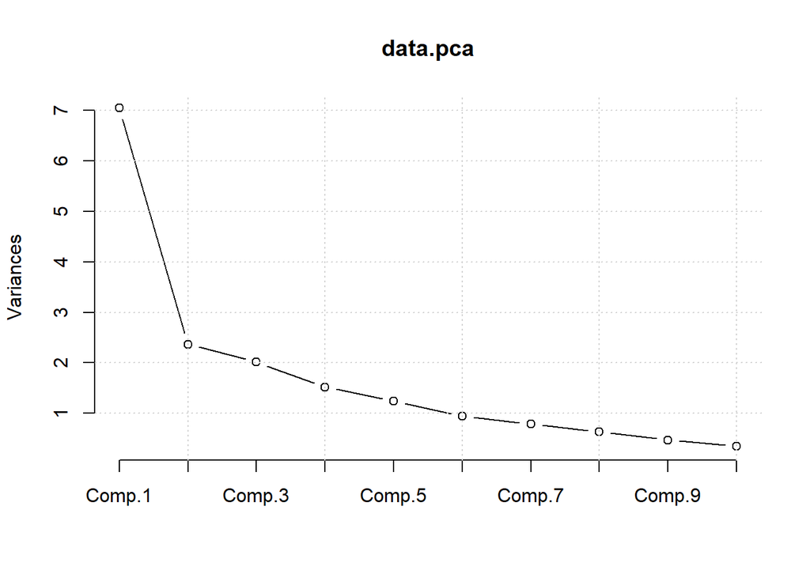

```r
## Scree plot, PCA tries to put maximum possible information in the first component, then maximum remaining information in the second and so on, until having something like shown in the scree plot below

screeplot(data.pca, type = "lines")
grid()
```

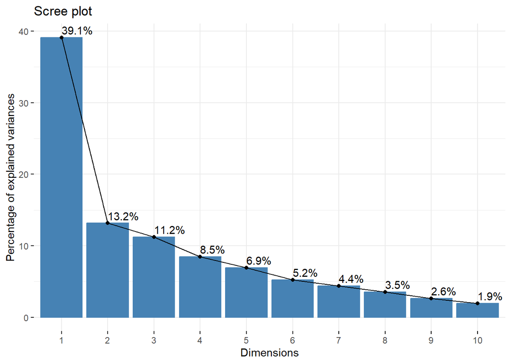

```r
##Scree Plot
#use the fviz_eig() function from the R package factoextra to display the eigenvalues of a #principal component analysis (PCA)


fviz_eig(data.pca, addlabels = TRUE)
```

```r
#The resulting graph can help determine the number of principal components to retain for later analysis.
```

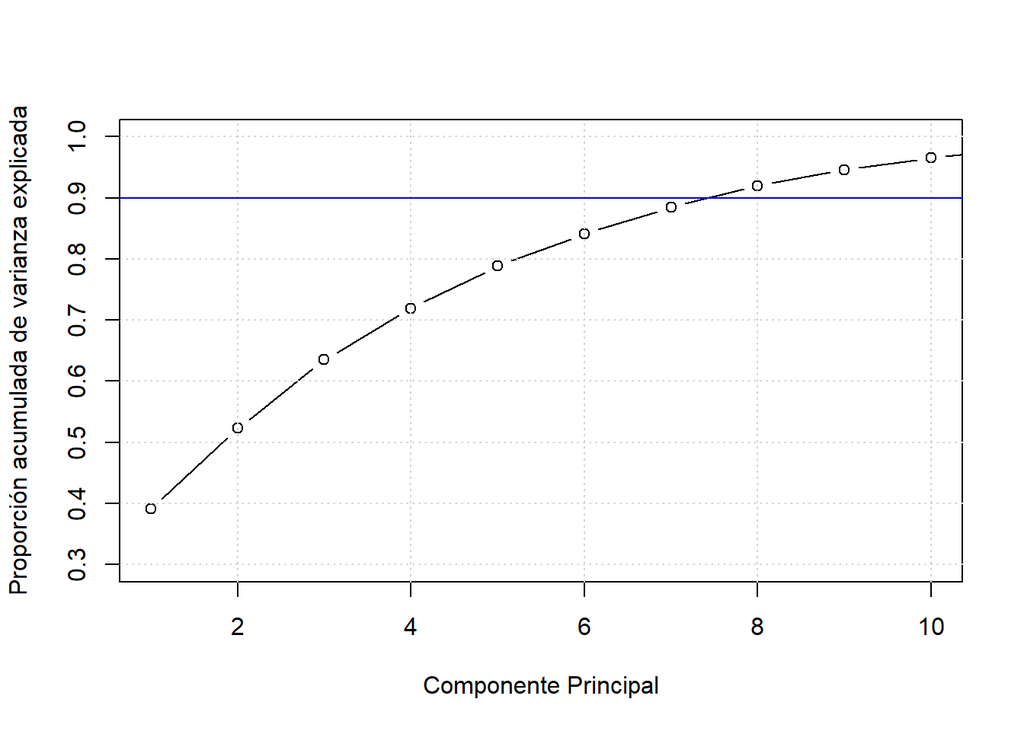

```r
##Another method to select components through cumulative variances and set a cumulative variance value

# Explained variance
pc.var <- data.pca$sdev^2

# Proportion of variation explained
pc.pvar <- pc.var / sum(pc.var)

# cumulative ratio
#shows the cumulative 90% of data variability, better representing the data
#to decide by size or shape of the data
plot(cumsum(pc.pvar),xlab = "Componente Principal", ylab = "Proporción acumulada de varianza explicada",xlim = c(1,10), ylim = c(0.3,1), type = 'b')
grid()

abline(h = 0.9, col = "blue")
```

```r
## Attributes or variables of data.pca

attributes(data.pca)
```

```
## $names
## [1] "sdev"     "loadings" "center"   "scale"    "n.obs"    "scores"   "call"
##
## $class
## [1] "princomp"
```

```r
## Interpretation of loadings

data.pca$loadings
```

```
##
## Loadings:
##                                 Comp.1 Comp.2 Comp.3 Comp.4 Comp.5 Comp.6
## Life.expectancy                  0.310  0.299                0.165  0.131
## Adult.Mortality                 -0.239 -0.388               -0.236
## infant.deaths                   -0.277  0.268         0.313  0.123 -0.167
## Alcohol                          0.204 -0.270 -0.243        -0.359
## percentage.expenditure           0.275  0.249 -0.143        -0.143 -0.463
## Hepatitis.B                     -0.101 -0.214                0.493 -0.492
## Measles                                 0.358 -0.327 -0.243         0.332
## BMI                                    -0.175  0.366  0.500 -0.159 -0.161
## under.five.deaths               -0.278  0.268         0.308  0.124 -0.163
## Polio                            0.126 -0.207 -0.462  0.342  0.202  0.146
## Total.expenditure                0.159         0.352         0.536
## Diphtheria                             -0.257 -0.489  0.205  0.240  0.111
## GDP                              0.283  0.202 -0.185        -0.108 -0.469
## Population                      -0.160  0.303         0.457 -0.218  0.179
## thinness..1.19.years            -0.321        -0.103 -0.250        -0.118
## thinness.5.9.years              -0.318               -0.238        -0.123
## Income.composition.of.resources  0.347
## Schooling                        0.275 -0.133  0.152
##                                 Comp.7 Comp.8 Comp.9 Comp.10 Comp.11 Comp.12
## Life.expectancy                                0.138  0.128   0.213
## Adult.Mortality                        -0.119 -0.301  0.160  -0.502   0.261
## infant.deaths                                 -0.383 -0.137   0.169
## Alcohol                                 0.366        -0.657
## percentage.expenditure                 -0.149        -0.105  -0.248
## Hepatitis.B                      0.315  0.523  0.192  0.121           0.137
## Measles                          0.427               -0.128  -0.262   0.486
## BMI                              0.311 -0.355  0.278                  0.311
## under.five.deaths                             -0.386 -0.138   0.171
## Polio                            0.119 -0.109 -0.136  0.225  -0.224  -0.482
## Total.expenditure                      -0.262        -0.546  -0.354  -0.139
## Diphtheria                      -0.163 -0.273  0.234 -0.114   0.314   0.316
## GDP                                    -0.210                -0.156
## Population                       0.234  0.240  0.372         -0.271  -0.248
## thinness..1.19.years             0.273 -0.268        -0.143   0.152  -0.268
## thinness.5.9.years               0.283 -0.258  0.121 -0.116   0.210  -0.290
## Income.composition.of.resources  0.285 -0.129 -0.176  0.205   0.114
## Schooling                        0.530  0.117 -0.456          0.208
```

[output cut: 17 more lines]

```
## Income.composition.of.resources          0.311  -0.760
## Schooling                       -0.406  -0.167   0.354
##
##                Comp.1 Comp.2 Comp.3 Comp.4 Comp.5 Comp.6 Comp.7 Comp.8 Comp.9
## SS loadings     1.000  1.000  1.000  1.000  1.000  1.000  1.000  1.000  1.000
## Proportion Var  0.056  0.056  0.056  0.056  0.056  0.056  0.056  0.056  0.056
## Cumulative Var  0.056  0.111  0.167  0.222  0.278  0.333  0.389  0.444  0.500
##                Comp.10 Comp.11 Comp.12 Comp.13 Comp.14 Comp.15 Comp.16 Comp.17
## SS loadings      1.000   1.000   1.000   1.000   1.000   1.000   1.000   1.000
## Proportion Var   0.056   0.056   0.056   0.056   0.056   0.056   0.056   0.056
## Cumulative Var   0.556   0.611   0.667   0.722   0.778   0.833   0.889   0.944
##                Comp.18
## SS loadings      1.000
## Proportion Var   0.056
## Cumulative Var   1.000
```

```r
#The loadings represent the correlation between the original variables and the principal components. Loadings tell you how much each original variable contributes to a specific principal component. High loadings (positive or negative) indicate that the original variable has a strong relationship with the principal component.
#If a variable has a high loading in the first principal component, it means that this variable is important to define that component.
#The higher the loading, the better the representation of the correlation between the original data and the CPA. The value depends on the researcher
```

```r
## Visualization of the components of interest

data.pca$loadings[ , 1:2]
```

```
##                                      Comp.1      Comp.2
## Life.expectancy                  0.31006892  0.29857763
## Adult.Mortality                 -0.23929625 -0.38788538
## infant.deaths                   -0.27697737  0.26758879
## Alcohol                          0.20409274 -0.27000270
## percentage.expenditure           0.27531904  0.24893102
## Hepatitis.B                     -0.10061981 -0.21402693
## Measles                         -0.09825740  0.35776505
## BMI                              0.01002165 -0.17505361
## under.five.deaths               -0.27768405  0.26828194
## Polio                            0.12645178 -0.20734510
## Total.expenditure                0.15881663 -0.08481128
## Diphtheria                       0.08768470 -0.25695316
## GDP                              0.28318938  0.20184587
## Population                      -0.15988994  0.30343500
## thinness..1.19.years            -0.32131310 -0.05318009
## thinness.5.9.years              -0.31781635 -0.08331136
## Income.composition.of.resources  0.34737868  0.03362721
## Schooling                        0.27541291 -0.13258207
```